# UVC datasets - exploring monitoring structure and herbivore assemblages

#### Seychelles

- Seychelles data are 7m radius point counts conducted at 21 reef sites in 1994, 2005, 2008, 2011, 2014, 2017.
- Sites were stratified according to habitat (granite = 7, patch = 7, carbonate = 7) and management status (12 = fished, 9 = MPAs)
- Reefs are the inhabited Seychelles islands, Mahe and Praslin
- Useful papers describing dataset methods: Graham et al. 2015 (Predicting climate-driven regime shifts…, Nature)

Across all surveys, `37` herbivore species were recorded, which are composed of:

| FG | species |
| --- | --- |
| Herbivore Browser | 5 |
| Herbivore Grazer | 15 |
| Herbivore Scraper | 17 |

Scrapers dominated herbivore assemblages on both fished and protected reefs, and browser biomass was slightly higher than grazer biomass after 1994 (i.e. after bleaching). High variability in browser biomass suggests that strong spatial variation in browser presence. This was less true for scrapers, for which biomass may be high at all reef sites. There was a weak protection effect apparent, with slightly higher biomass of all feeding groups in protected sites.

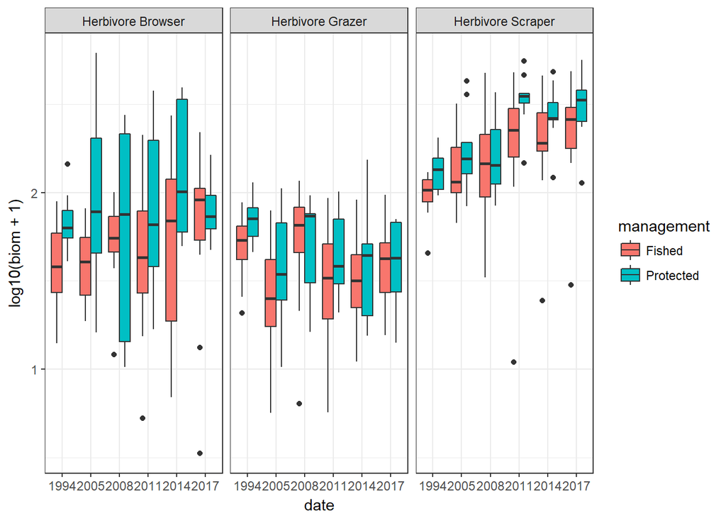

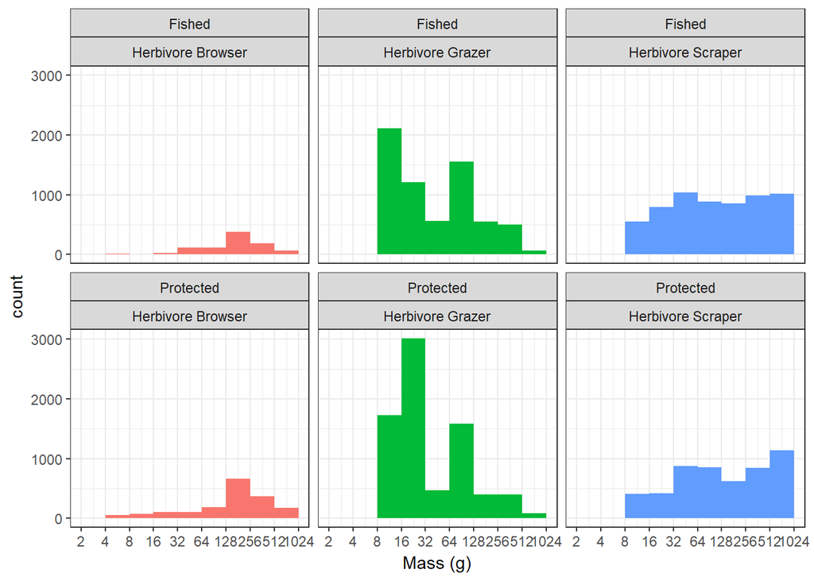

**Common herbivore species**

Considering common species as those that are high in abundance or biomass (i.e. mean biomass across UVC replicates at each site).

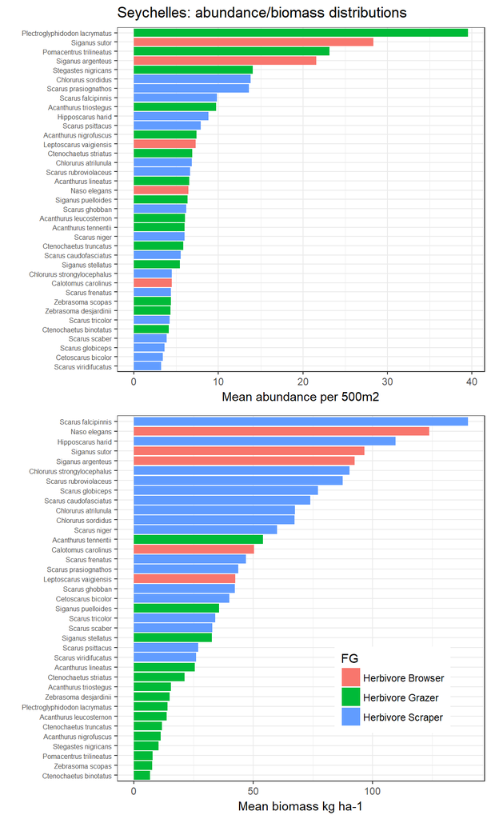

#### Maldives

# biomass ditribution across functional groups

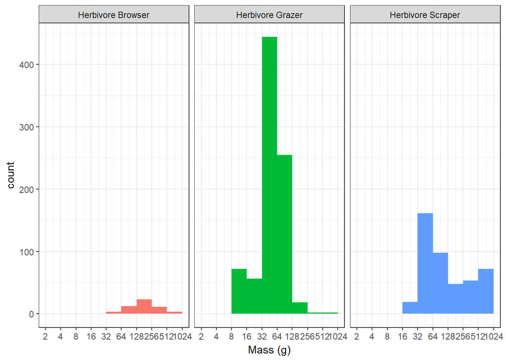

*Browsers few but large, grazers smaller but many, scrapers more equally spread in both

# common herbivore species

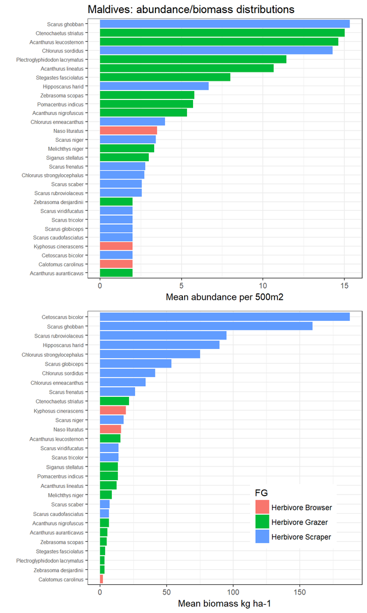

#### GBR

```r
library(ggplot2)
library(tidyverse)

load('data/wio_gbr_herb_master.Rdata')
gbr <- herb %>% filter(dataset=='GBR')
```

# biomass by functional group

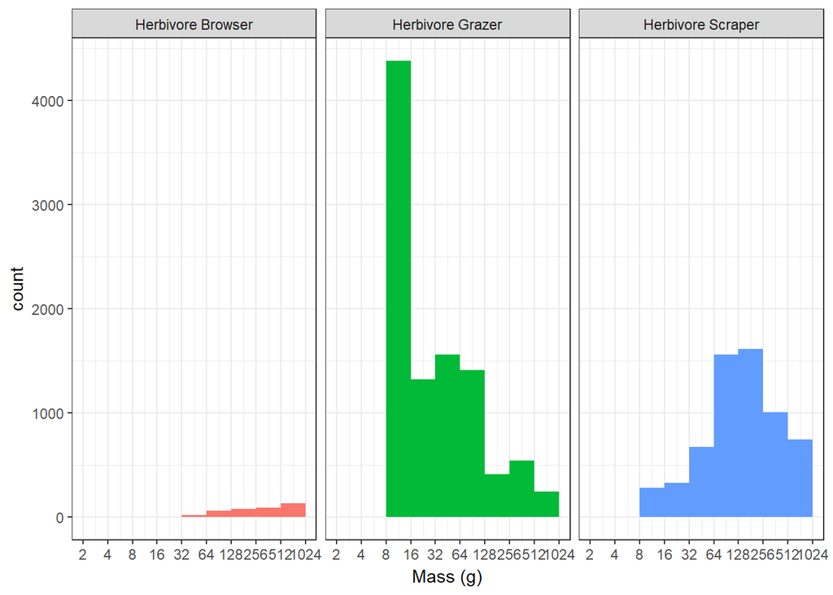

# common species

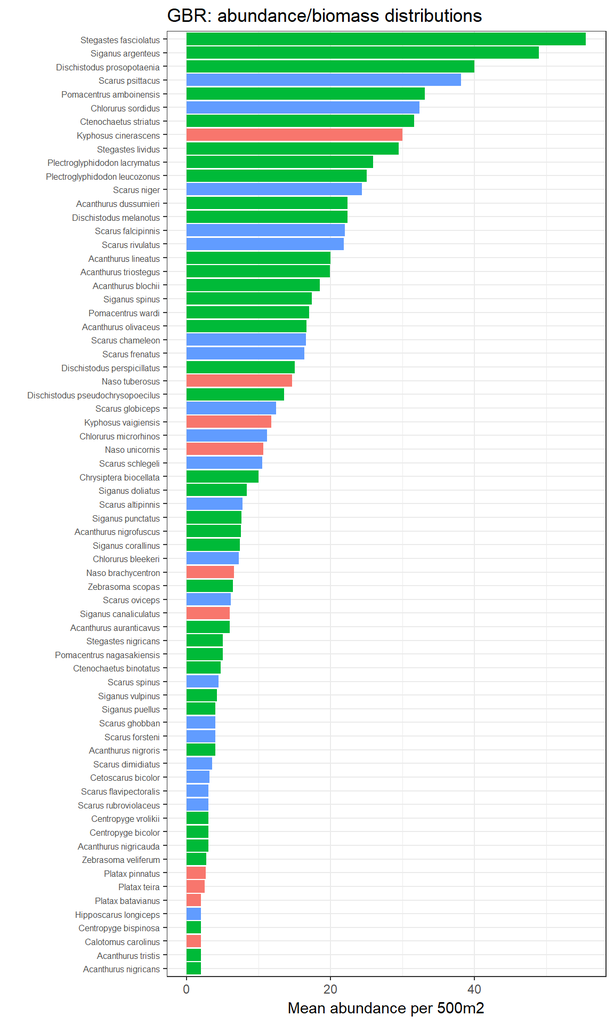

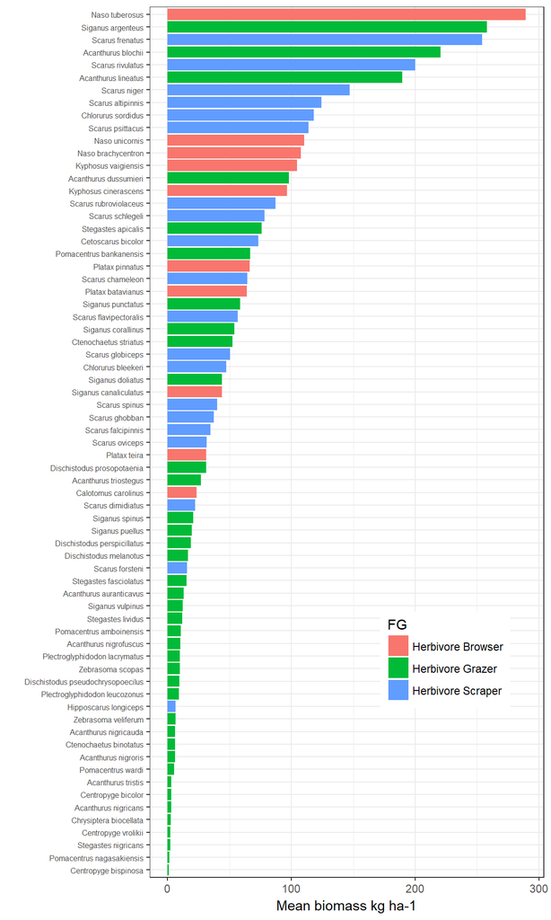

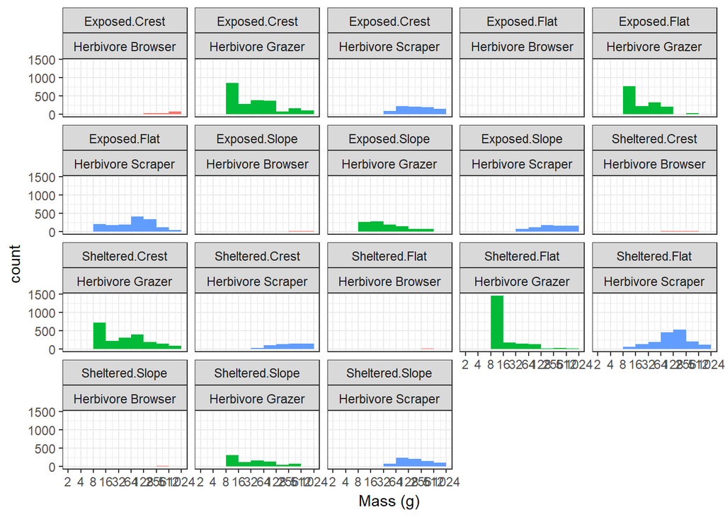

```r
ggplot(gbr, aes(log(mass.g, 2), fill=FG)) + geom_histogram(breaks=c(1:10)) +
  facet_wrap(habitat~FG) + theme(legend.position='none') +
  scale_x_continuous(breaks=c(1:10), labels=c(2^c(1:10))) + labs (x='Mass (g)')
```

Ugly biomass gradient across habitat levels - find it somewhat useful